# DataAnalysis - Postprocessing Results MaxQuant

08 März 2023, 16:27:15

# 1 Global Parameters

```r
###############################
#
#define settings
#
###############################

GET_SAMPLE_NAMES <- TRUE # if set to FALSE define it in the next line
#sample_names_user <- c()

unique <- params$unique  # how many peptides should be at least necessary to identify a protein


# which types should be evaluated TRUE or FALSE could be used
RAZOR <- TRUE
UNIQUE <- TRUE
LFQ <- FALSE

# define path of the proteinGroups.txt file(s)
path = params$path
```

# 2 Introduction

## 2.1 Unique | Razor&Unique procedure

Filtering:

- `Potential.contaminant != "+"` -> remove where contaminants
- `Reverse != "+"`-> remove where reverse = +
- `Only.identified.by.site != "+"` -> remove where only identified by site = +
- `data[name] >= unique` -> keep only identifications which have greater or equal number (defined via variable `unique`) of `razor/unique peptides` | typically this is set to 1 or 2

`Data analysis` show the number of identified proteins and the heatmap. In `Summary` the final results are visualized as boxplot and a table with the summarized values is shown.

## 2.2 LFQ-Procedure

Filtering:

- `Potential.contaminant != "+"` -> remove where contaminants = +
- `Reverse != "+"`-> remove where reverse = +
- `Only.identified.by.site != "+"` -> remove where only identified by site = +

Then the `log2`of the LFQ intensities is calculated and all `-Inf` values were substituted by NA using the following command: `lfq[lfq == -Inf] <- NA`

`Data analysis` show the number of identified proteins and the heatmap. In `Summary` the final results are visualized as boxplot and a table with the summarized values is shown.

# 3 Load required packages and functions

```r
# load libraries
library(tidyverse)
library(dplyr)
library(pheatmap)
library(ggplot2)
library(reshape2)
library(knitr)
library(plotly)
# load functions
source("filtering_function.R")
print("loading sucessful")
```

```
## [1] "loading sucessful"
```

# 4 Data Analysis

The txt-files of the defined folder are read in, processed and filtered automatically. This section shows the code, heatmaps and also some summary statistics.

```r
infile <- read.csv(path, dec=".", sep="\t")
res_raw <- list(infile)
########## get sample names
if (GET_SAMPLE_NAMES == TRUE){
  #get sample names
  tmp <- colnames(res_raw[[1]])
  tmp <- tmp[grep("Razor...unique.peptides.",tmp)]
  tmp <- sub(".*Razor...unique.peptides.", "",tmp)
  sample_names_raw <- tmp
  rm(tmp)
  #create sample names
  sample_names_razor <- paste("Razor...unique.peptides.",sample_names_raw, sep="")
  sample_names_unique <- paste("Unique.peptides.",sample_names_raw, sep="")
  sample_names_lfq <- paste("LFQ.intensity.",sample_names_raw, sep="")
} else {
    res_raw[[1]] <- res_raw[[1]] %>%
       rename_with(~ paste("Razor_", sample_names_user, sep = ""),
                   starts_with("Razor...unique.peptides.")) %>%
       rename_with(~ paste("Unique_", sample_names_user, sep = ""),
                   starts_with("Unique.peptides.")) %>%
       rename_with(~ paste("LFQ_", sample_names_user, sep = ""),
                   starts_with("LFQ.intensity."))
    # get column names
    sample_names_razor <- colnames(res_raw[[i]][grep("Razor_",
                                                colnames(res_raw[[i]]))])
    sample_names_unique <- colnames(res_raw[[i]][grep("Unique_",
                                                colnames(res_raw[[i]]))])
    sample_names_lfq <- colnames(res_raw[[i]][grep("LFQ_",
                                                 colnames(res_raw[[i]]))])
}

########## create result data frame & result lists
# create data frame for razor
results_2gether_razor <- data.frame(matrix(ncol = length(sample_names_razor), nrow = 1))
colnames(results_2gether_razor) <- sample_names_razor
#create data frame for unique
results_2gether_unique <- data.frame(matrix(ncol = length(sample_names_unique), nrow = 1))
colnames(results_2gether_unique) <- sample_names_unique
#create data frame for lfq
results_2gether_lfq <- data.frame(matrix(ncol = length(sample_names_lfq), nrow = 1))
colnames(results_2gether_lfq) <- sample_names_lfq

#results lists
results_razor <- list()
results_unique <- list()
results_lfq <- list()

########## perform evaluation
if (RAZOR == TRUE) {
  cat("\n")
  cat("##","Razor","\n")
  cat("\n")
    data_raw <- as.data.frame(res_raw[[1]])
    data <- filtering(data_raw)
    fasta <- data$Fasta.headers
    results <- data.frame(matrix(ncol = length(sample_names_razor), nrow = nrow(data)))
    colnames(results) <- sample_names_razor
    i <- 0
    for (i in 1:length(sample_names_razor)){
      name <- sample_names_razor[i]
      tmp <- (data[name] >= unique)
      results[i] <- tmp
      cat(name,"<br/>",sum(tmp, na.rm = TRUE),"<br/>")
    }
    results_2gether_razor[1,] <- sapply(results,function(x)sum(x, na.rm = TRUE))
    results$FASTA <- data$Fasta.headers
    results_razor[[1]] <- results
    cat("\n")

        #create heatmaps
    paletteLength <- 2
    myColor <- colorRampPalette(c("navy", "white",
                                  "firebrick3"))(paletteLength)
      data4pheatmap <- results[,-ncol(results)]
      data4pheatmap <- data4pheatmap*1
      data4pheatmap[data4pheatmap == 0] <- NA
      # remove NA rows
      ind <- apply(data4pheatmap, 1, function(x) all(is.na(x)))
      data4pheatmap_clear <- data4pheatmap[!ind,]
      data4pheatmap_clear[is.na(data4pheatmap_clear)] <- 0
      if (ncol(data4pheatmap_clear) < 2){
        cat("\n")
        cat("##"," No heatmap possible. Too less columns in the result
            table.","\n")
      } else {
        pheatmap(data4pheatmap_clear,
                 legend_breaks = c(0,1),
                 color = myColor,
                 treeheight_row = 10,
                 angle_col ="45",
                 treeheight_col = 10,
                 legend = TRUE,
                 labels_row = rep("",nrow(data4pheatmap)),
                 labels_col = sample_names_raw)
        cat("\n")
      }

}
```

## 4.1 Razor

Razor…unique.peptides.1_a_01  
762  
Razor…unique.peptides.1_a_02  
775  
Razor…unique.peptides.1_b_01  
757  
Razor…unique.peptides.1_b_02  
761  
Razor…unique.peptides.2_a_01  
418  
Razor…unique.peptides.2_a_02  
408  
Razor…unique.peptides.2_b_01  
657  
Razor…unique.peptides.2_b_02  
652  
Razor…unique.peptides.3_a_01  
448  
Razor…unique.peptides.3_a_02  
445  
Razor…unique.peptides.3_b_01  
258  
Razor…unique.peptides.3_b_02  
268  
Razor…unique.peptides.4_b_01  
319  
Razor…unique.peptides.4_b_02  
365

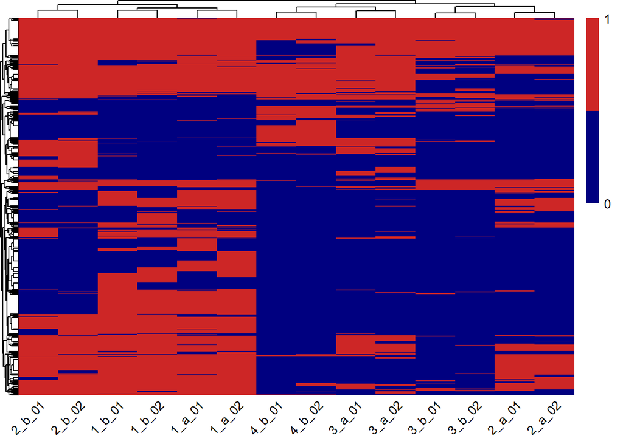

```r
if (UNIQUE == TRUE) {
  cat("\n")
  cat("##","Unique","\n")
  cat("\n")
    data_raw <- as.data.frame(res_raw[[1]])
    data <- filtering(data_raw)
    results <- data.frame(matrix(ncol = length(sample_names_unique), nrow = nrow(data)))
    colnames(results) <- sample_names_unique
    i <- 0
    for (i in 1:length(sample_names_unique)){
      name <- sample_names_unique[i]
      tmp <- (data[name] >= unique)
      results[i] <- tmp
      cat(name,"<br/>",sum(tmp, na.rm = TRUE),"<br/>")
    }
    results_2gether_unique[1,] <- sapply(results,function(x)sum(x, na.rm = TRUE))
    results$FASTA <- data$Fasta.headers
    results_unique[[1]] <- results
    cat("\n")
    #create heatmaps
    paletteLength <- 2
    myColor <- colorRampPalette(c("navy", "white",
                                  "firebrick3"))(paletteLength)
      data4pheatmap <- results[,-ncol(results)]
      data4pheatmap <- data4pheatmap*1
      data4pheatmap[data4pheatmap == 0] <- NA
      # remove NA rows
      ind <- apply(data4pheatmap, 1, function(x) all(is.na(x)))
      data4pheatmap_clear <- data4pheatmap[!ind,]
      data4pheatmap_clear[is.na(data4pheatmap_clear)] <- 0
      if (ncol(data4pheatmap) < 2){
        cat("\n")
        cat("##"," No heatmap possible. Too less columns in the result
            table.","\n")
      } else {
        pheatmap(data4pheatmap_clear,
                 legend_breaks = c(0,1),
                 color = myColor,
                 treeheight_row = 10,
                 angle_col ="45",
                 treeheight_col = 10,
                 legend = TRUE,
                 labels_row = rep("",nrow(data4pheatmap)),
                 labels_col = sample_names_raw)
        cat("\n")
      }
}
```

## 4.2 Unique

Unique.peptides.1_a_01  
755  
Unique.peptides.1_a_02  
764  
Unique.peptides.1_b_01  
743  
Unique.peptides.1_b_02  
747  
Unique.peptides.2_a_01  
410  
Unique.peptides.2_a_02  
399  
Unique.peptides.2_b_01  
647  
Unique.peptides.2_b_02  
641  
Unique.peptides.3_a_01  
439  
Unique.peptides.3_a_02  
435  
Unique.peptides.3_b_01  
248  
Unique.peptides.3_b_02  
257  
Unique.peptides.4_b_01  
310  
Unique.peptides.4_b_02  
353

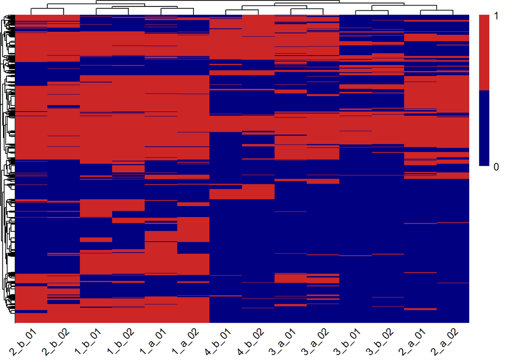

```r
if (LFQ == TRUE) {
  cat("\n")
  cat("##","LFQ","\n")
  cat("\n")
    data_raw <- as.data.frame(res_raw[[1]])
    data <- filtering(data_raw)

    results <- data.frame(matrix(ncol = length(sample_names_lfq), nrow = nrow(data)))
    colnames(results) <- sample_names_lfq
    i <- 0
    for (i in 1:length(sample_names_lfq)){
      name <- sample_names_lfq[i]
      tmp <- log2(data[name])
      tmp[tmp == -Inf] <- NA
      results[i] <- tmp
      cat(name,"<br/>",sum(!is.na(tmp)),"<br/>")

    }


    results_2gether_lfq[1,] <- sapply(results,function(x)sum(!is.na(x)))
    results$FASTA <- data$Fasta.headers
    results_lfq[[1]] <- results

    cat("\n")

    #create heatmaps
    paletteLength <- 50
    myColor <- colorRampPalette(c("navy", "white",
                                  "firebrick3"))(paletteLength)
      data4pheatmap <- results[,-ncol(results)]
      data4pheatmap <- data4pheatmap*1
      data4pheatmap[data4pheatmap == 0] <- NA
      # remove NA rows
      ind <- apply(data4pheatmap, 1, function(x) all(is.na(x)))
      data4pheatmap_clear <- data4pheatmap[!ind,]
      data4pheatmap_clear[is.na(data4pheatmap_clear)] <- 0
      if (ncol(data4pheatmap) < 2){
        cat("\n")
        cat("##"," No heatmap possible. Too less columns in the result
            table.","\n")
      } else {
        pheatmap(data4pheatmap_clear,
                 color = myColor,
                 treeheight_row = 10,
                 angle_col ="45",
                 treeheight_col = 10,
                 legend = TRUE,
                 labels_row = rep("",nrow(data4pheatmap)),
                 labels_col = sample_names_raw)
        cat("\n")
      }
}
```

# 5 Summary

```r
# show summary
if (RAZOR == TRUE){
  cat("\n")
  cat("##"," Summary Razor","\n")
  print(kable(results_2gether_razor))

  ggplot(melt(results_2gether_razor),aes(x = variable, y = value)) +
  geom_boxplot() +
  xlab("Sample name") +
  scale_x_discrete(labels = sample_names_raw) +
  theme(axis.text.x = element_text(angle = 90)) +
  labs(title = "Razor")
}
```

## 5.1 Summary Razor

| Razor…unique.peptides.1_a_01 | Razor…unique.peptides.1_a_02 | Razor…unique.peptides.1_b_01 | Razor…unique.peptides.1_b_02 | Razor…unique.peptides.2_a_01 | Razor…unique.peptides.2_a_02 | Razor…unique.peptides.2_b_01 | Razor…unique.peptides.2_b_02 | Razor…unique.peptides.3_a_01 | Razor…unique.peptides.3_a_02 | Razor…unique.peptides.3_b_01 | Razor…unique.peptides.3_b_02 | Razor…unique.peptides.4_b_01 | Razor…unique.peptides.4_b_02 |
| --- | --- | --- | --- | --- | --- | --- | --- | --- | --- | --- | --- | --- | --- |
| 762 | 775 | 757 | 761 | 418 | 408 | 657 | 652 | 448 | 445 | 258 | 268 | 319 | 365 |

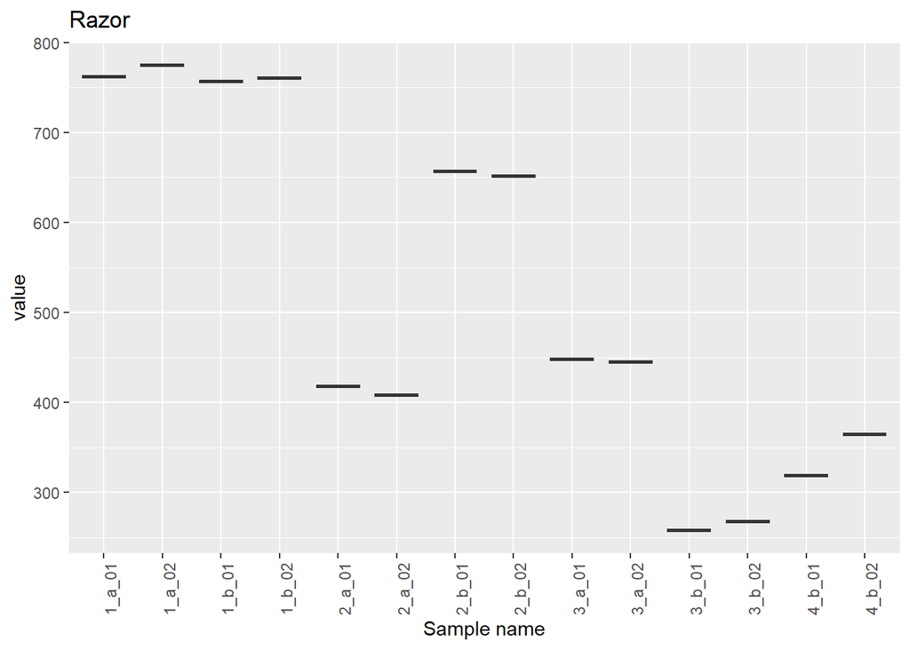

```r
if (UNIQUE == TRUE){
  cat("\n")
  cat("##"," Summary Unique","\n")
  print(kable(results_2gether_unique))

  ggplot(melt(results_2gether_unique),aes(x = variable, y = value)) +
  geom_boxplot() +
  xlab("Sample name") +
  scale_x_discrete(labels = sample_names_raw) +
  theme(axis.text.x = element_text(angle = 90)) +
  labs(title = "Unique")
}
```

## 5.2 Summary Unique

| Unique.peptides.1_a_01 | Unique.peptides.1_a_02 | Unique.peptides.1_b_01 | Unique.peptides.1_b_02 | Unique.peptides.2_a_01 | Unique.peptides.2_a_02 | Unique.peptides.2_b_01 | Unique.peptides.2_b_02 | Unique.peptides.3_a_01 | Unique.peptides.3_a_02 | Unique.peptides.3_b_01 | Unique.peptides.3_b_02 | Unique.peptides.4_b_01 | Unique.peptides.4_b_02 |
| --- | --- | --- | --- | --- | --- | --- | --- | --- | --- | --- | --- | --- | --- |
| 755 | 764 | 743 | 747 | 410 | 399 | 647 | 641 | 439 | 435 | 248 | 257 | 310 | 353 |

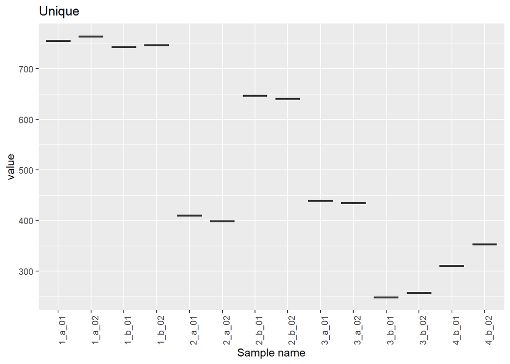

```r
if (LFQ == TRUE){
  cat("\n")
  cat("##"," Summary LFQ","\n")
  print(kable(results_2gether_lfq))

  ggplot(melt(results_2gether_lfq),aes(x = variable, y = value)) +
  geom_boxplot() +
  xlab("Sample name") +
  scale_x_discrete(labels = sample_names_raw) +
  theme(axis.text.x = element_text(angle = 90)) +
  labs(title = "LFQ")
}

# save results
results_final <- data.frame(results_2gether_razor,results_2gether_unique,results_2gether_lfq)
# get rid of NA columns
results_final <- results_final[,colSums(is.na(results_final))<nrow(results_final)]
write.csv2(results_final, file = paste(params$pathRDS,"_summary.csv",sep=""))
saveRDS(results_razor, file = paste(params$pathRDS,"_Razor.RDS",sep=""))
saveRDS(results_unique, file = paste(params$pathRDS,"_Unique.RDS",sep=""))
saveRDS(results_lfq, file = paste(params$pathRDS,"_LFQ.RDS",sep=""))
```

# 6 Used time

```
## [1] "Time used for analysis: 0.12 minutes"
```